##### Explain how you would count a single player’s total offensive rebounds for the season. Please reference specific items in the data you would use.

For this first part I care about rebounds, it looks like the second column, EVENTMSGTYPE, can tell me rebounds. I’ll filter by `EVENTMSGTYPE == 4`, then I’d like to group by team, then by player, then use `summarize(n())` to get the number of instances of each for each individual player. I did this in lines 34-42 of the attached script. a. Provide a list of the top 10 offensive rebounders (total rebounds) in the last six minutes of the first quarter. Display the output in a chart or graph of your choosing.

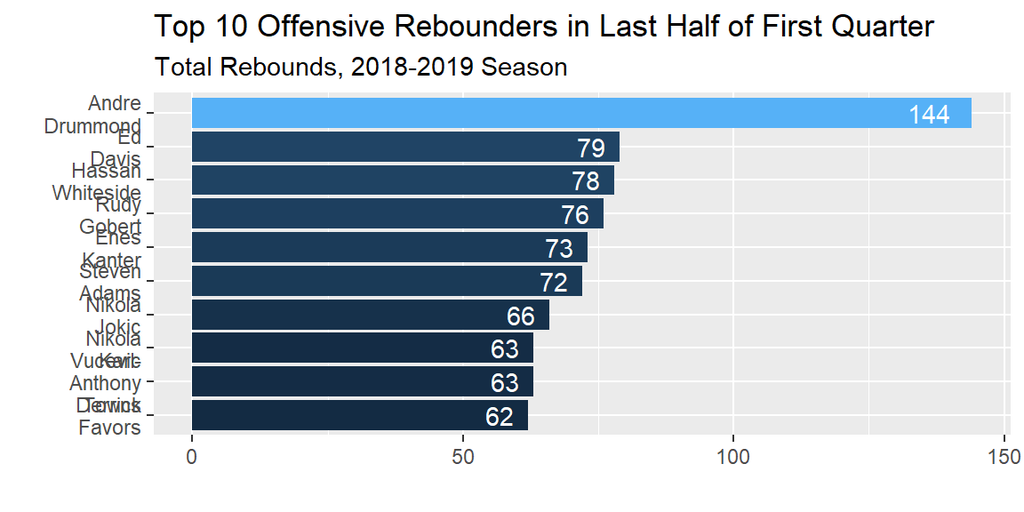

##### (B) What was the most common two-man pair played by each team in the following window: 3 minutes remaining in Q1 to 9 minutes remaining in Q2? Display the output in a chart or graph of your choosing

To accomplish part B, I’m going to need to take each player id in home and away and put them into one dataframe. Then after preprocessing I used a for loop with teh `combn` function to extract the most common occurrences of pairs of players by minutes played in the given time window. The for loop then pasted the team, the player pair, and the minutes played into a blank dataframe. I then split the pair column, joined the playerid with its player’s name, and pasted them back together. I plotted by division to make the plot easier to read.

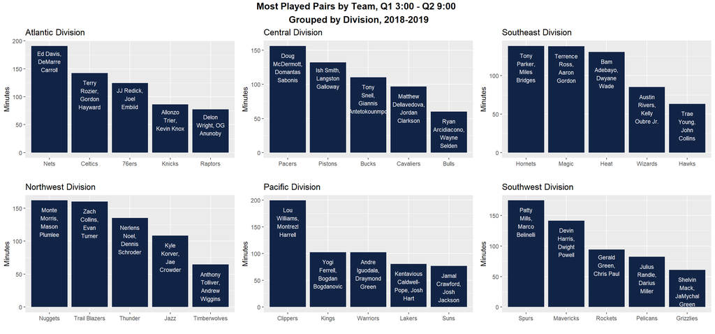

##### Use the embedded file below that contains player height and weight. Pick one team and calculate the average ACWR (using the assumptions below) of their players, weighted by minutes played. Do so for each game of the season and display the results on a graph of your choosing.

For this portion, I’m going to use minutes per player from `nbastatR` package, game_logs function. Before we calculate load, we need to make sense of the csv with player height and weight. I’m going to going to have to separate them into two columns, then convert to one new height column before calculating BMI. I’ll join BMI with the hawks_2018 dataframe using player ID as a key, calculate daily load, and then calculate the load sums for L<sub>a</sub> and L<sub>c</sub>. I’ll divide L<sub>a</sub> by L<sub>c</sub> to derive ACWR and plot individual for each date and mean.

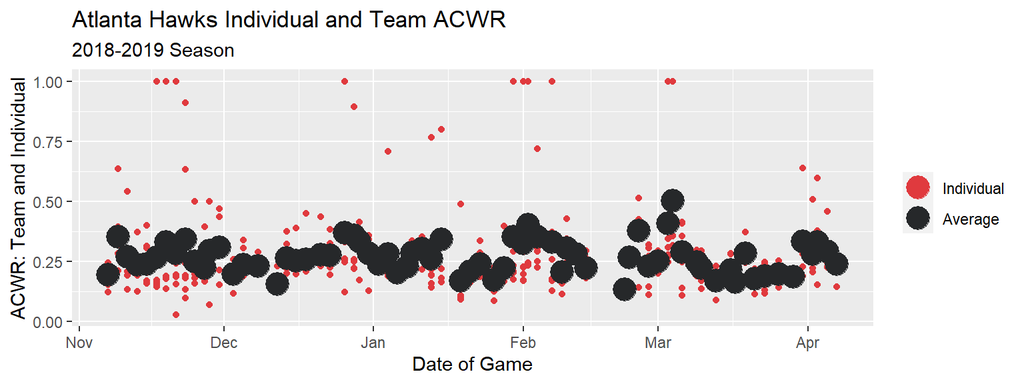

##### Determine if the team’s performance changes based on its ACWR. Analyze team performance overall, offensive and defensive four factors.

I ran linear regression models using ACWR as the predictor and team plus minus, field goal percentage (2 and 3 point FG), free throw percentage, offensive rebounds, defensive rebounds, steals, blocks and turnovers. All had no clear linear association with ACWR. This leads me to believe that ACWR may not be an accurate predictor in game-based performance metrics, however there are plenty of other high-yield performance metrics that can be associated with ACWR that may be proxies for game performance, like game RPE, subjective soreness, or perceived fatigue.